# Section 2: Basics

Author

Ben Moolman

Practice basic plots with this dataset:

```r
## install.packages("palmerpenguins") in console
library(palmerpenguins)
library(tidyverse)
theme_set(theme_minimal())
penguins
```

```
# A tibble: 344 × 8
   species island    bill_length_mm bill_depth_mm flipper_length_mm body_mass_g
   <fct>   <fct>              <dbl>         <dbl>             <int>       <int>
 1 Adelie  Torgersen           39.1          18.7               181        3750
 2 Adelie  Torgersen           39.5          17.4               186        3800
 3 Adelie  Torgersen           40.3          18                 195        3250
 4 Adelie  Torgersen           NA            NA                  NA          NA
 5 Adelie  Torgersen           36.7          19.3               193        3450
 6 Adelie  Torgersen           39.3          20.6               190        3650
 7 Adelie  Torgersen           38.9          17.8               181        3625
 8 Adelie  Torgersen           39.2          19.6               195        4675
 9 Adelie  Torgersen           34.1          18.1               193        3475
10 Adelie  Torgersen           42            20.2               190        4250
# ℹ 334 more rows
# ℹ 2 more variables: sex <fct>, year <int>
```

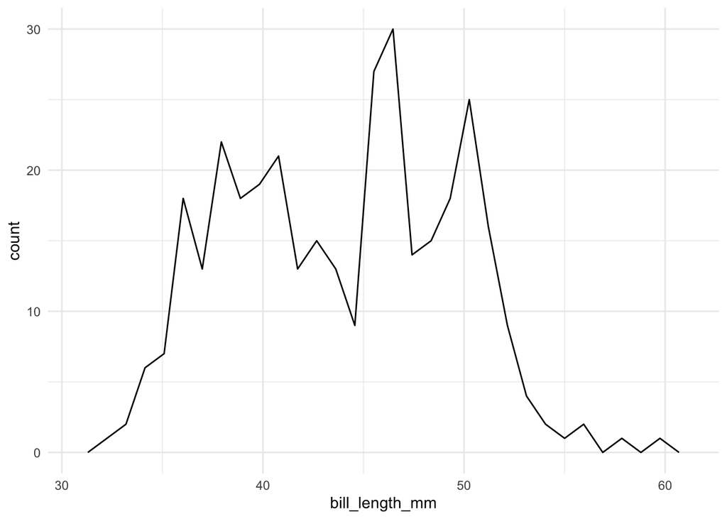

```r
## single quantitative frequency plot exploring bill_length_mm
ggplot(data = penguins, aes(x = bill_length_mm)) +
  geom_freqpoly()
```

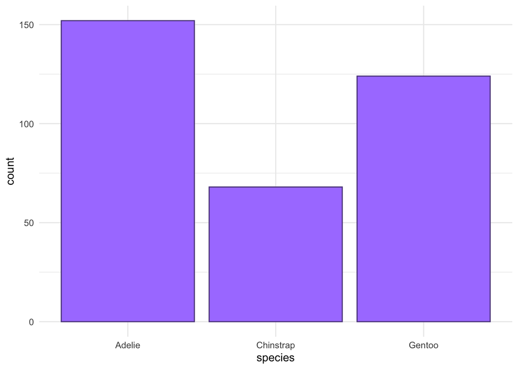

```r
## single categorical variable counting each type of species
ggplot(data = penguins, aes(x = species)) +
  geom_bar(colour = "mediumpurple4", fill = "mediumpurple1")
```

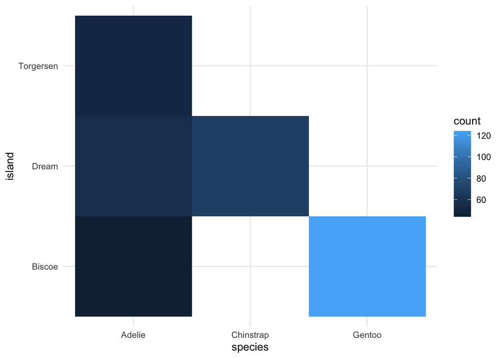

```r
## two categorical variables
ggplot(data = penguins, aes(x = species, y = island)) +
  geom_bin_2d()
```

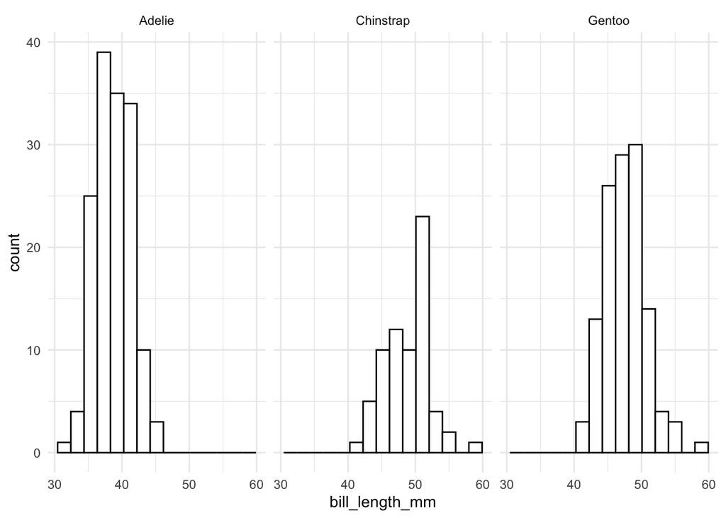

```r
## facet use to split up by categorical variable (species)
ggplot(data = penguins, aes(x = bill_length_mm)) +
  geom_histogram(colour = "black", fill = "white", bins = 15) +
  facet_wrap(~ species)
```

```r
## using <STAT>
ggplot(data = penguins, aes(x = species)) +
  geom_bar(stat = "count") ## don't need stat = "count" because it's the default.
```

[output not shown]

```r
## Change the df so that we have two columns: species and count
penguins_counts <- penguins |> group_by(species) |>
  summarise(count = n())

## use <STAT> on this new df with "identity"
ggplot(data = penguins_counts, aes(x = species, y = count)) +
  geom_bar(stat = "identity")
```

[output not shown]

```r
## This is the same as the one above
ggplot(data = penguins_counts, aes(x = species, y = count)) +
  geom_col()
```

[output not shown]

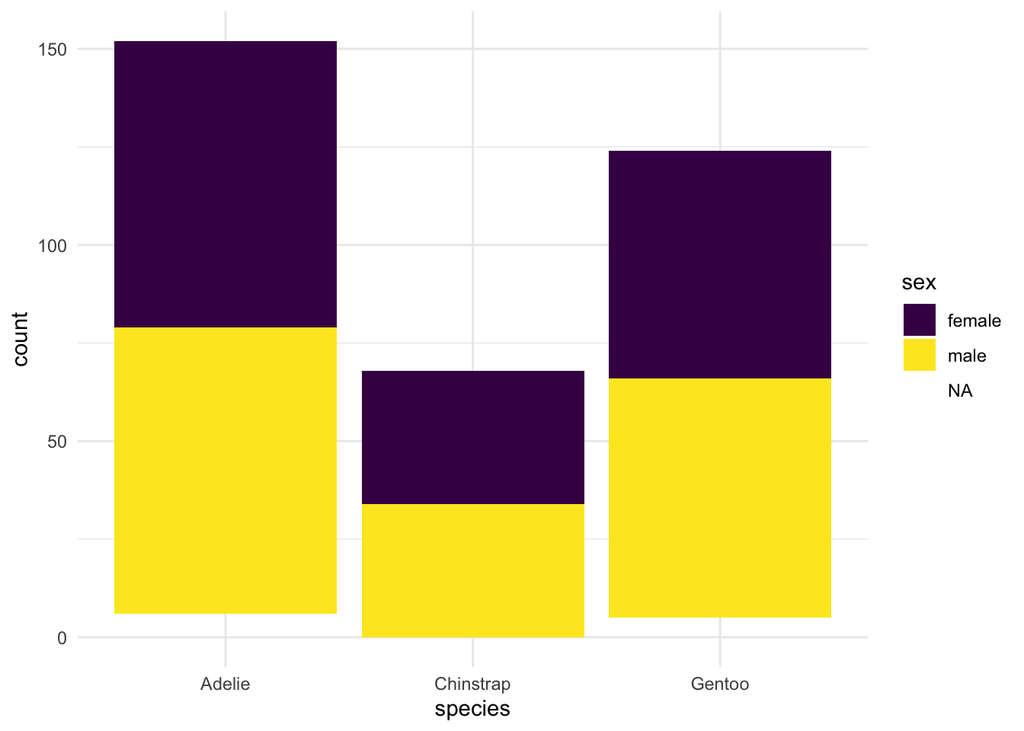

```r
## using <POSITION>
ggplot(data = penguins, aes(x = species, fill = sex)) +
  geom_bar(position = "stack") + ## don't need "stack" because it's default
  scale_fill_viridis_d()
```

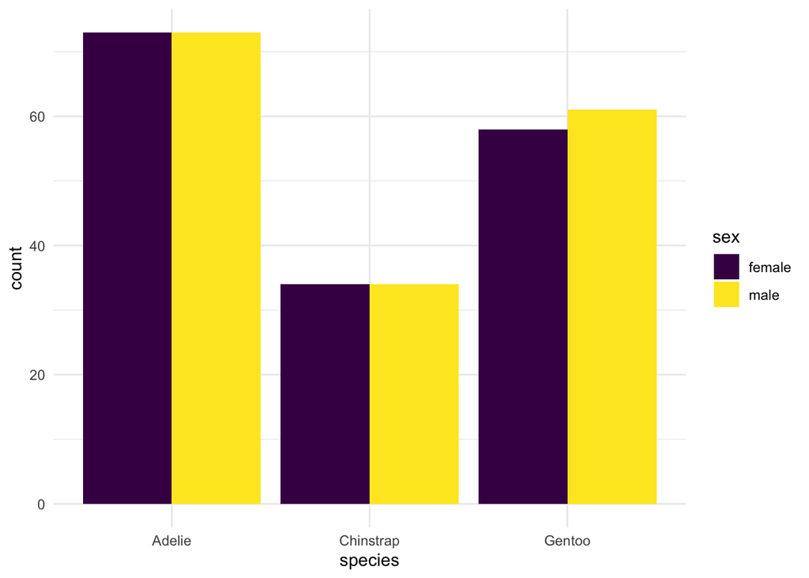

```r
## NA values are messing up widths of bars

## Remove missing NA values
# penguins_na <- penguins |> na.omit ## gets rid of any row w/ NA value
## or
penguins_na <- penguins |> filter(!is.na(sex)) ## gets rid of any row in sex col w/ NA value

## dodge helps to put side by side bar plots
ggplot(data = penguins_na, aes(x = species, fill = sex)) +
  geom_bar(position = "dodge") +
  scale_fill_viridis_d()
```

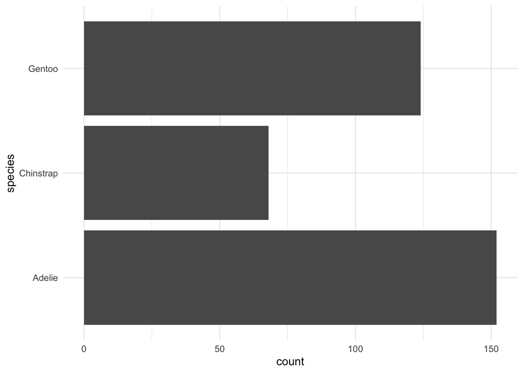

```r
## using <COORDINATE>

## flips x and y axis
ggplot(data = penguins, aes(x = species)) +
  geom_bar() +
  coord_flip()
```

#### Exercise 1

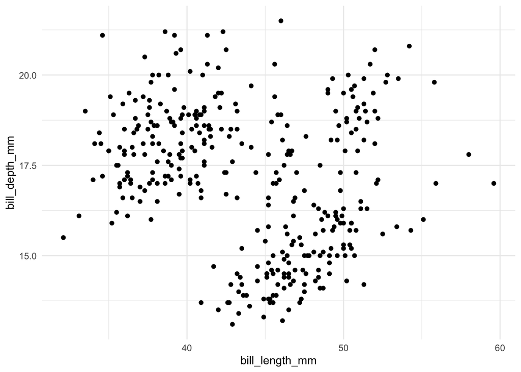

```r
ggplot(data = penguins, aes(x = bill_length_mm, y = bill_depth_mm)) +
  geom_point()
```

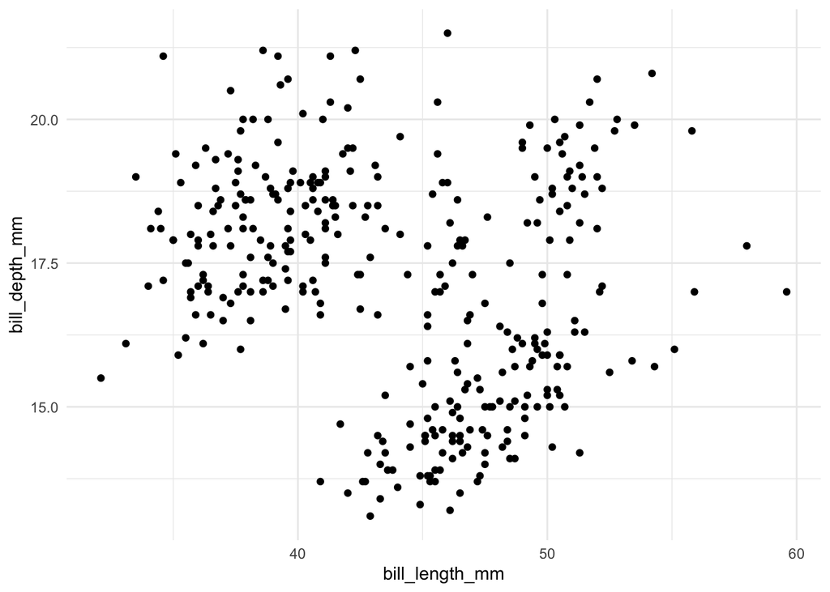

```r
ggplot(data = penguins, aes(x = bill_length_mm, y = bill_depth_mm)) +
  geom_point(stat = "identity",
             position = "identity") +
  facet_null() +
  coord_cartesian()
```

# Section 2.3 Your Turn Exercises

## Exercise 1

Make another plot of bill_length_mm with a different geom that is used for a single quantitative variable.

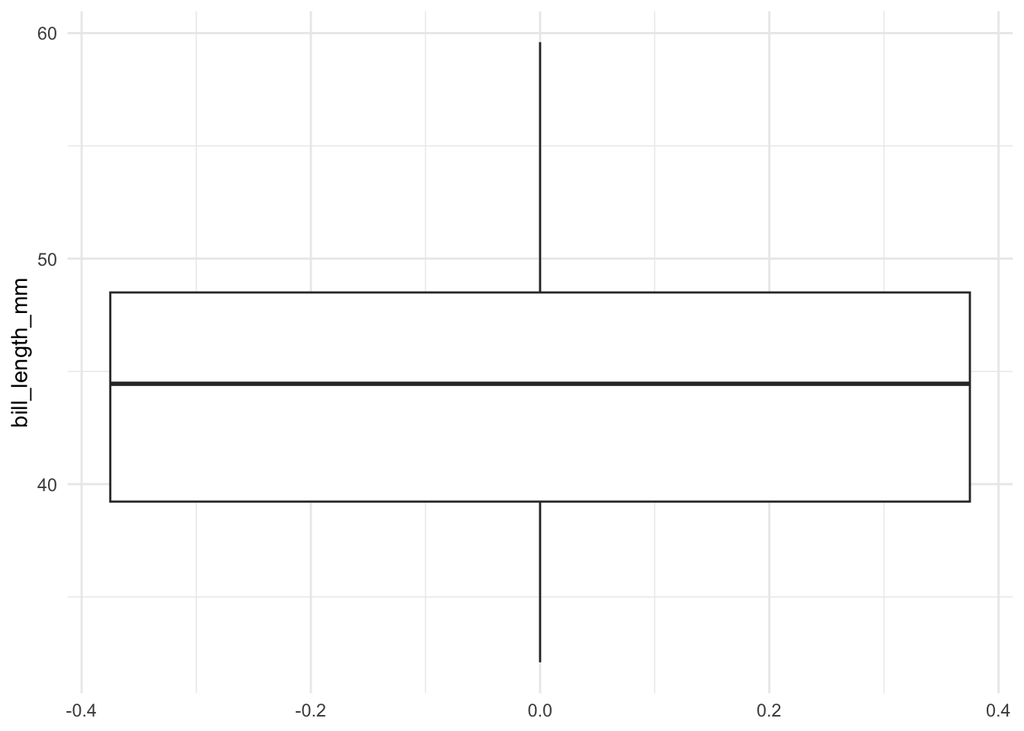

```r
ggplot(data = penguins, aes(y = bill_length_mm)) +
  geom_boxplot()
```

## Exercise 2

Create a plot of a quantitative and a categorical variable in the penguins data set.

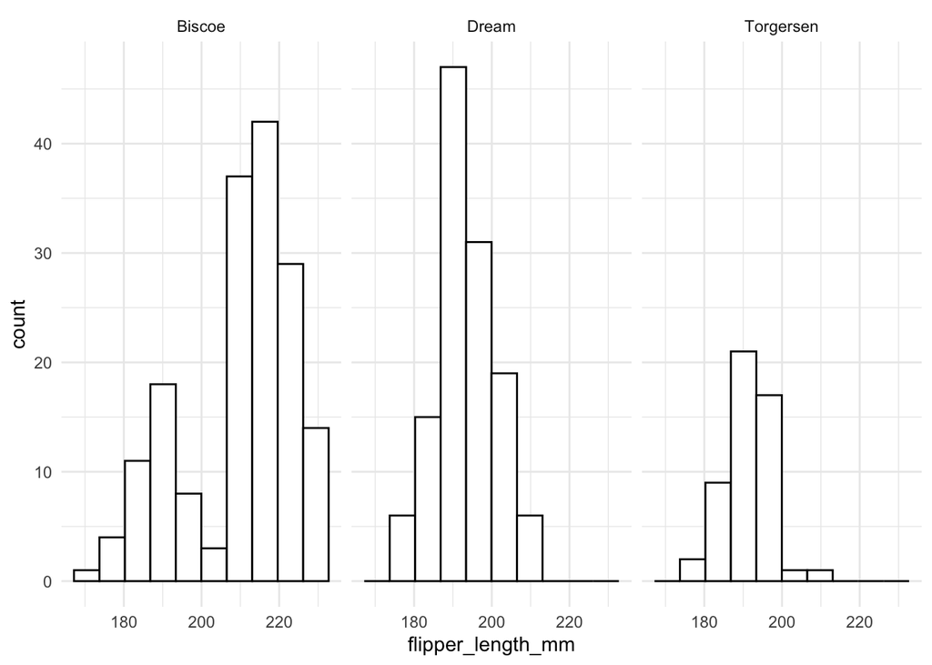

```r
ggplot(data = penguins, aes(x = flipper_length_mm)) +
  geom_histogram(colour = "black", fill = "white", bins = 10) +
  facet_wrap(~ island)
```

## Exercise 3

Modify the frequency plot made with geom_freqpoly() to use colour in two different ways:

1. change the colour of the line to any colour that R knows. A list of some colours can be found at this link.
2. add a colour aesthetic to make three different frequency lines, one for each species of penguin.

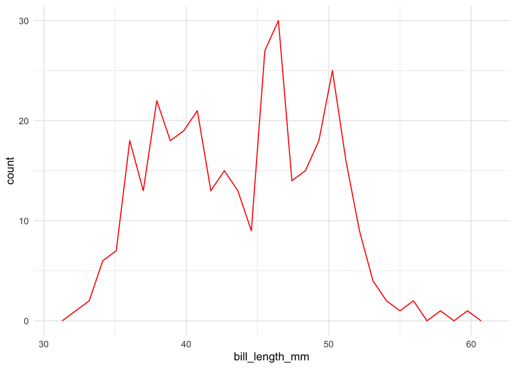

```r
## a.
ggplot(data = penguins, aes(x = bill_length_mm)) +
  geom_freqpoly(colour = "red")
```

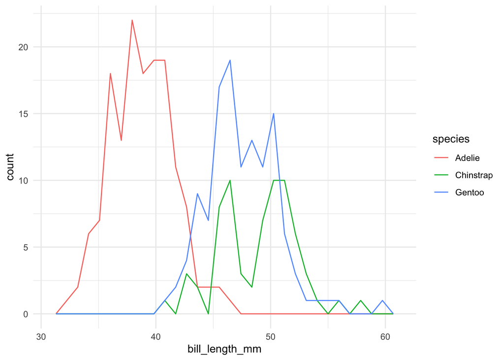

```r
## b.
ggplot(data = penguins, aes(x = bill_length_mm)) +
  geom_freqpoly(aes(colour = species))
```

## Exercise 4

Modify the scatterplot and smoother so that a. the points are coloured by species, but there is only one smoother instead of three. b. there are three different coloured smoothers (one for each species) but the points are all the same colour.

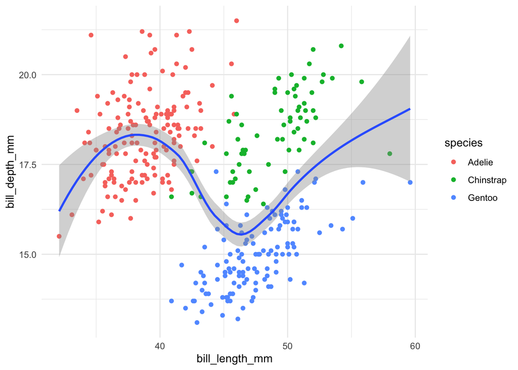

```r
## a.
ggplot(data = penguins, aes(x = bill_length_mm,
                            y = bill_depth_mm)) +
  geom_point(aes(colour = species)) +
  geom_smooth()
```

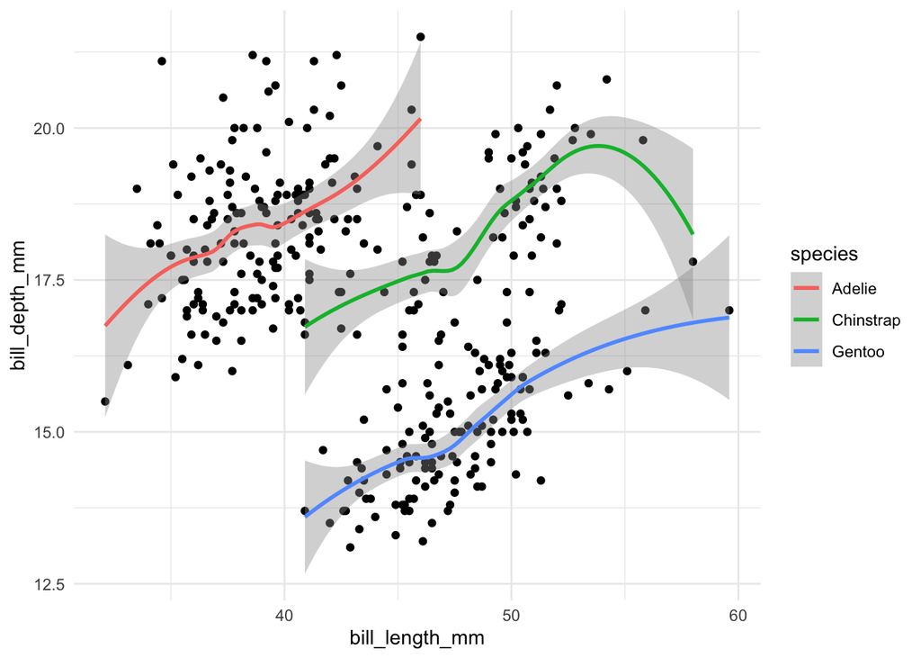

```r
## b.
ggplot(data = penguins, aes(x = bill_length_mm,
                            y = bill_depth_mm)) +
  geom_point() +
  geom_smooth(aes(colour = species))
```

## Exercise 5

Construct another graph that explicitly uses all 7 grammar of graphics parameters (you may set some of these parameters to be the default values, but you should do so explicitly).

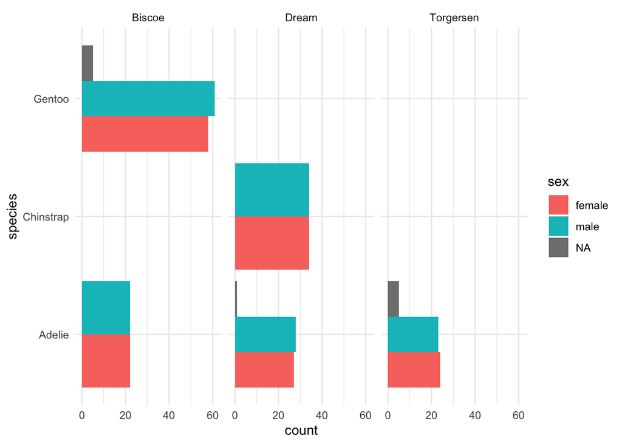

```r
ggplot(data = penguins, aes(x = species, fill = sex)) +
  geom_bar(stat = "count", position = "dodge") +
  facet_wrap(~ island) +
  coord_flip()
```

## Exercise 6

Create two different graphs that differ only by 1 of the 7 grammar of graphics parameters. Then, show your two graphs (but not your code) to a partner and see if they can identify which graphics parameter has been modified.

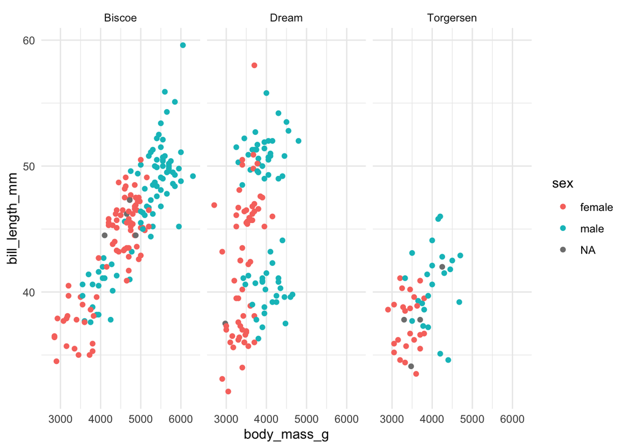

```r
ggplot(data = penguins, aes(x = body_mass_g, y = bill_length_mm)) +
  geom_point(aes(colour = sex)) +
  facet_wrap(~ island)
```

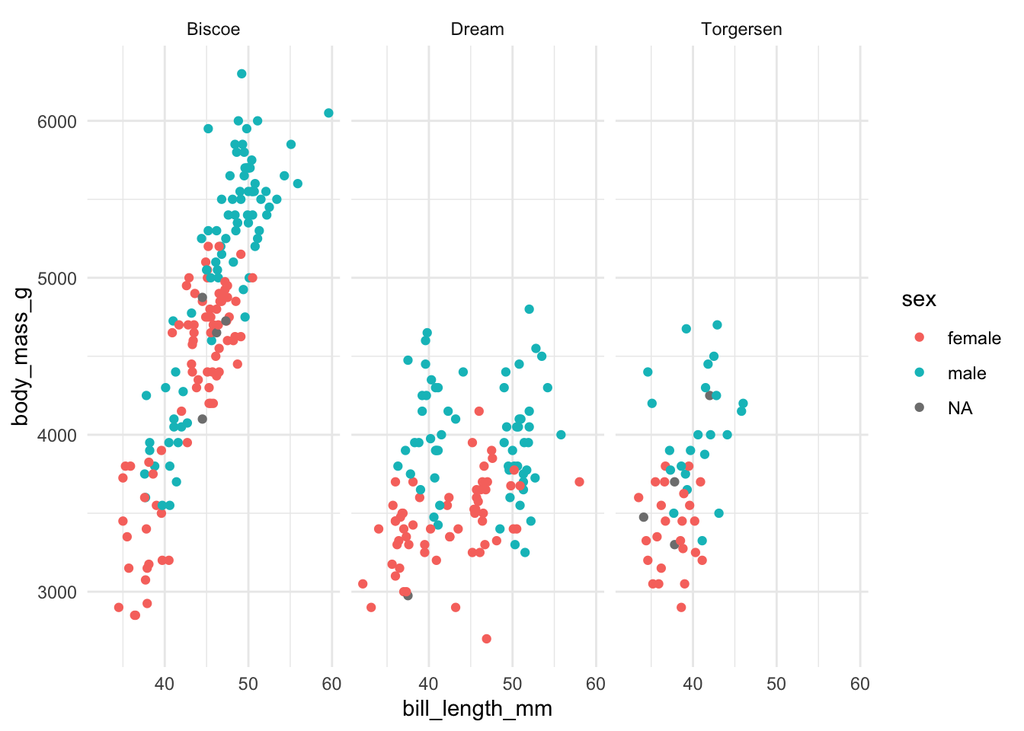

```r
ggplot(data = penguins, aes(x = body_mass_g, y = bill_length_mm)) +
  geom_point(aes(colour = sex)) +
  facet_wrap(~ island) +
  coord_flip()
```